# nci60_eda.R

kkumbier

2021-03-25

```r
library(data.table)
library(tidyverse)
library(xpose4)
library(rcellminer)
library(rcellminerData)
library(glmnet)
library(PRROC)
library(caret)
library(viridis)
library(parallel)
library(iRF)
library(superheat)
setwd('~/github/cancer_translator/')
source('scripts/utilities.R')

train.prop <- 0.8
model <- glm_fit
```

The NCI60 data, describing bioactivity for 60 CCLs are available through rcellminer. Below we consider a subset of drug classes from the ORACL paper, derived from matching MoA annotations in rcellminer against class annotations in the ORACL data.

For each of these compounds, we load bioactivity data from the NCI60 cell line set as `x.activity`. We impute NA values as the median within cell lines.

```r
# Set compound key for select classes
class.key <- c(
  MT='Tu',
  DNA='(TOP2|Ds|Df|DHFR|AM|GARTF)',
  VEGFR='VEGFR',
  A7='A7',
  YK='YK',
  PIK3='PIK3',
  HDAC='HDAC',
  mTOR='MTOR',
  AKT='AKT'
)

# Read in MOA data from NCI60
nsc.set <- unique(c(getMoaToCompounds(), recursive=TRUE))
moa <- getMoaStr(nsc.set)

moa.split <- unlist(str_split(moa, ','))
moa.table <- data.frame(MoA=moa.split) %>%
  group_by(MoA) %>%
  summarize(Count=n()) %>%
  arrange(desc(Count))

# Map MOA to compound class
class <- sapply(class.key, function(k) str_detect(moa, k))

# Drop multi- and 0- target compounds
id.drop <- rowSums(class) != 1
class.id <- names(class.key)[apply(class[!id.drop,], MAR=1, which)]
class.id <- as.factor(class.id)
nsc.set <- nsc.set[!id.drop]

# Read in bioactivity data for compound set
x.activity <- getDrugActivityData(nsc.set)

# Impute NAs as median within cell line
x.activity <- apply(x.activity, MAR=2, median_impute)
print(dim(x.activity))
```

```
## [1] 396  60
```

### Downsample for class imbalance

Here we downsample for imbalance in compound classes. **Note:** If upsampling instead, we need to split train/test to not including training samples in test set. Discuss up/down sampling - should models be giving equal weight across drug classes?

```r
xbalanced <- downSample(x.activity, class.id)
class.id <- xbalanced$Class
x.activity <- select(xbalanced, -Class)
print(dim(x.activity))
```

```
## [1] 126  60
```

We visualize bioactivity patterns within our compound set below. Heatmap rows correspond to different compounds and columns cell lines. Compound classes cluster relative to PC1 and PC2 but show high variability.

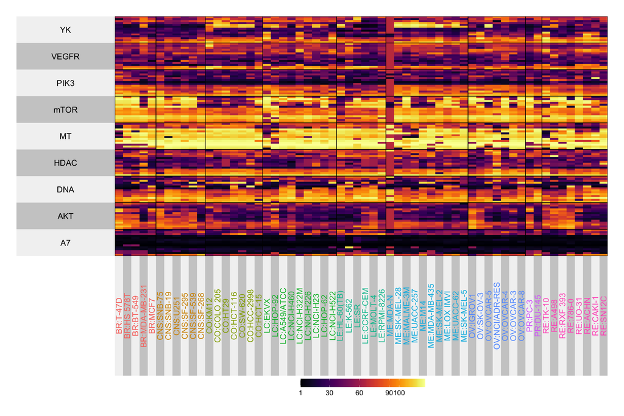

```r
# Bioactivity heatmap visualization
xplot <- apply(x.activity, MAR=2, rank)
type <- as.factor(str_remove_all(colnames(xplot), ':.*'))
type.pal <- scales::hue_pal()(length(unique(type)))

superheat(xplot,
          membership.rows=class.id,
          membership.cols=type,
          pretty.order.rows=TRUE,
          pretty.order.cols=TRUE,
          heat.pal=inferno(100),
          bottom.label='variable',
          bottom.label.text.col=type.pal[type],
          bottom.label.size=0.5,
          bottom.label.text.angle=90)
```

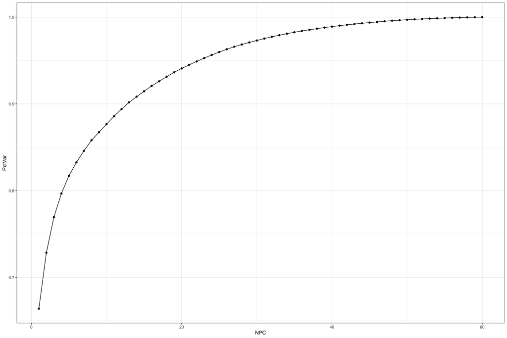

```r
# Bioactivity PCA plot visualization
xpca <- prcomp(apply(x.activity, MAR=2, rank))
data.frame(PctVar=cumsum(xpca$sdev ^ 2) / sum(xpca$sdev ^ 2)) %>%
  mutate(NPC=1:n()) %>%
  ggplot(aes(x=NPC, y=PctVar)) +
  geom_point() +
  geom_line() +
  theme_bw()
```

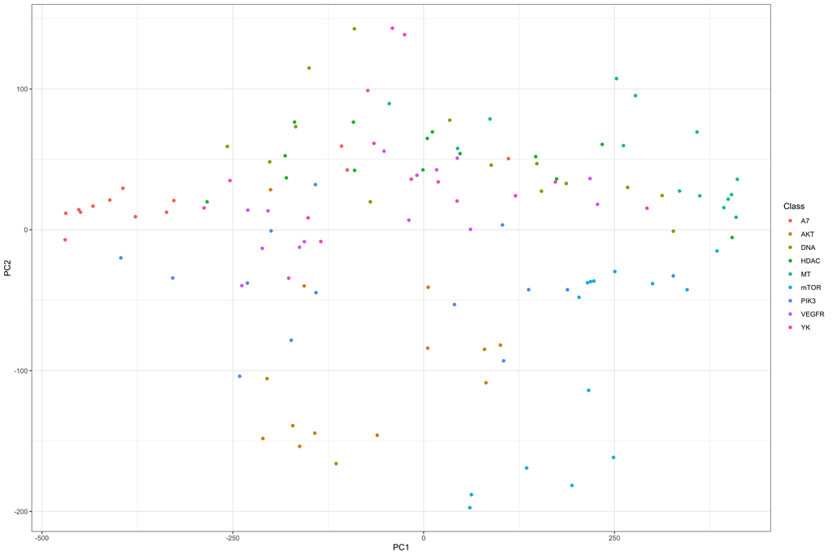

```r
data.frame(xpca$x, Class=class.id) %>%
  ggplot(aes(x=PC1, y=PC2, col=Class)) +
  geom_point() +
  theme_bw()
```

## Predictive modeling

Below, we consider the problem of predicting which compound class a given compound belongs to, and how many cell lines are required for prediction.

```r
y <- as.numeric(class.id) - 1
x <- x.activity
ncell <- 2:10
n.replicate <- 50

fits <- mclapply(1:n.replicate, function(i) {
  set.seed(i)

  # Generate sample split
  id.train <- createDataPartition(y, p=train.prop)$Resample1
  id.test <- setdiff(1:nrow(x), id.train)

  # Fit RF to predict moa from bioactivity
  out <- model(x, y, id.train, id.test, ncell)
  return(list(accuracy=out$accuracy, selected=out$selected))
}, mc.cores=10)

accuracy <- lapply(fits, function(f) as.matrix(f$accuracy))
selected <- lapply(fits, function(f) f$selected)
```

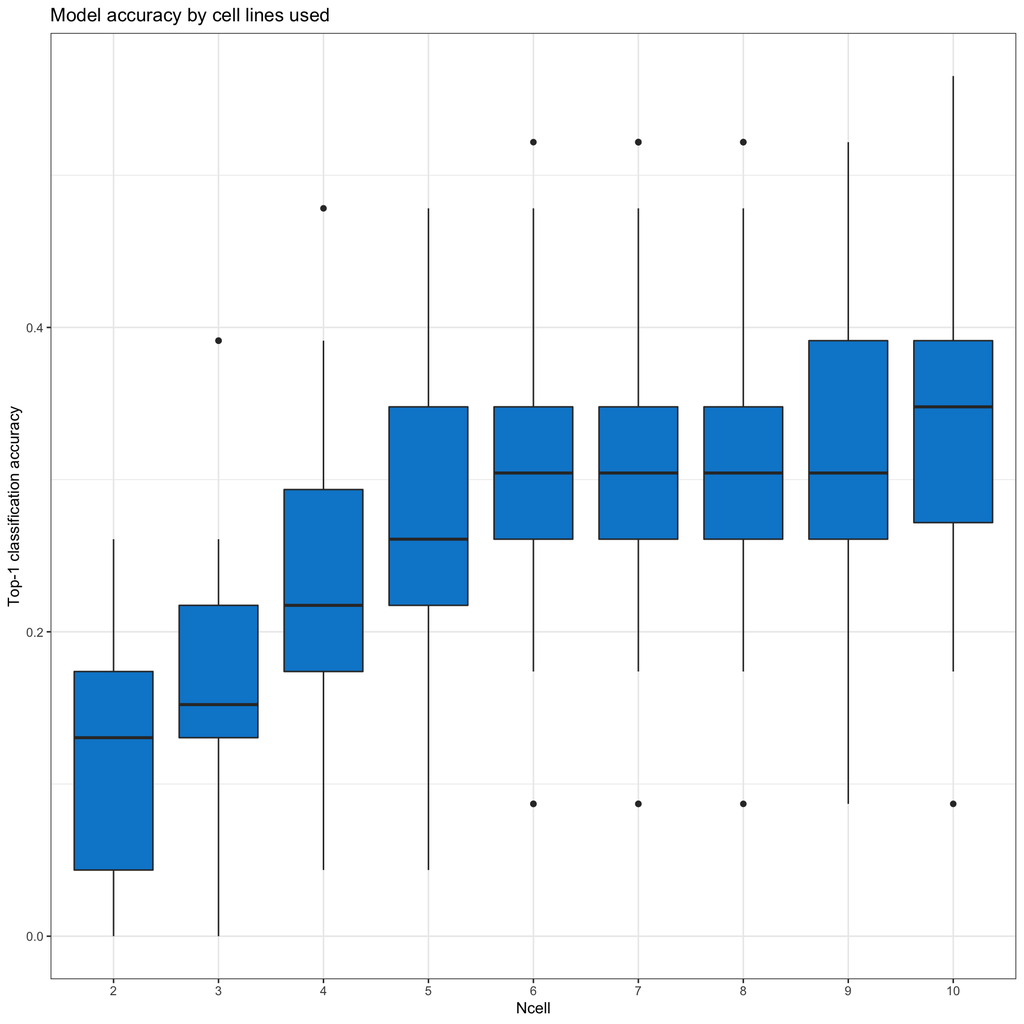

```r
reshape2::melt(accuracy) %>%
  mutate(Ncell=as.factor(ncell[Var1])) %>%
  ggplot(aes(x=Ncell, y=value)) +
  geom_boxplot(fill='#0388D1') +
  theme_bw() +
  ylab("Top-1 classification accuracy") +
  ggtitle('Model accuracy by cell lines used')
```

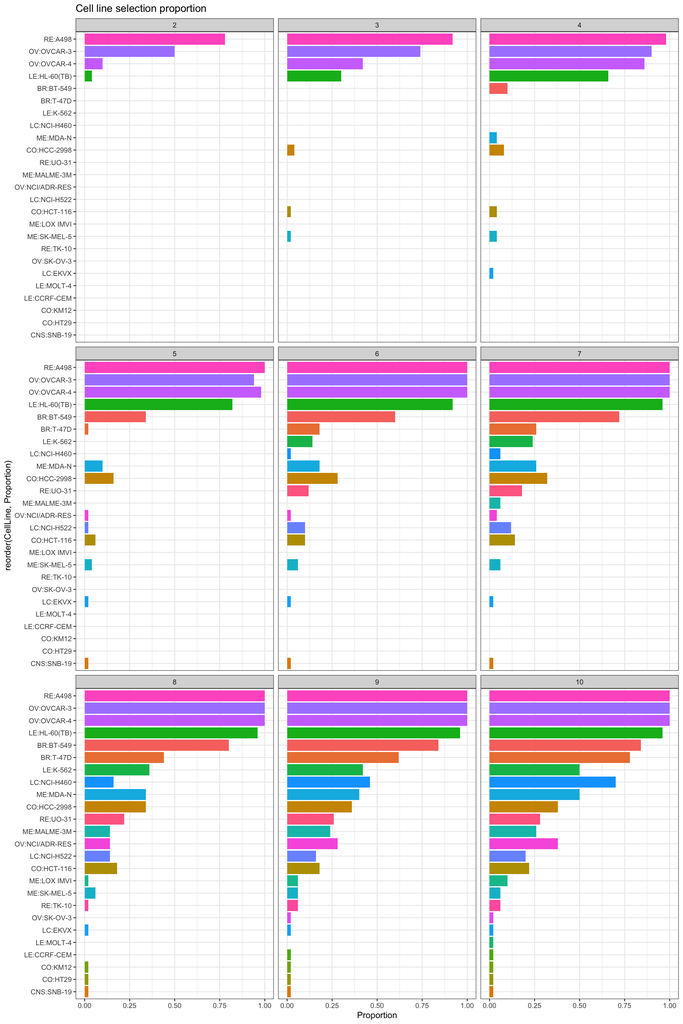

```r
reshape2::melt(selected) %>%
  rename(CellLine=Var1, Ncell=Var2, Rep=L1) %>%
  mutate(Ncell=ncell[Ncell]) %>%
  group_by(CellLine, Ncell) %>%
  summarize(Proportion=mean(value)) %>%
  filter(Proportion != 0) %>%
  ggplot(aes(x=reorder(CellLine, Proportion), y=Proportion)) +
  facet_wrap(~Ncell) +
  geom_bar(stat='identity', aes(fill=CellLine)) +
  coord_flip() +
  theme_bw() +
  theme(legend.position='none') +
  ggtitle('Cell line selection proportion')
```

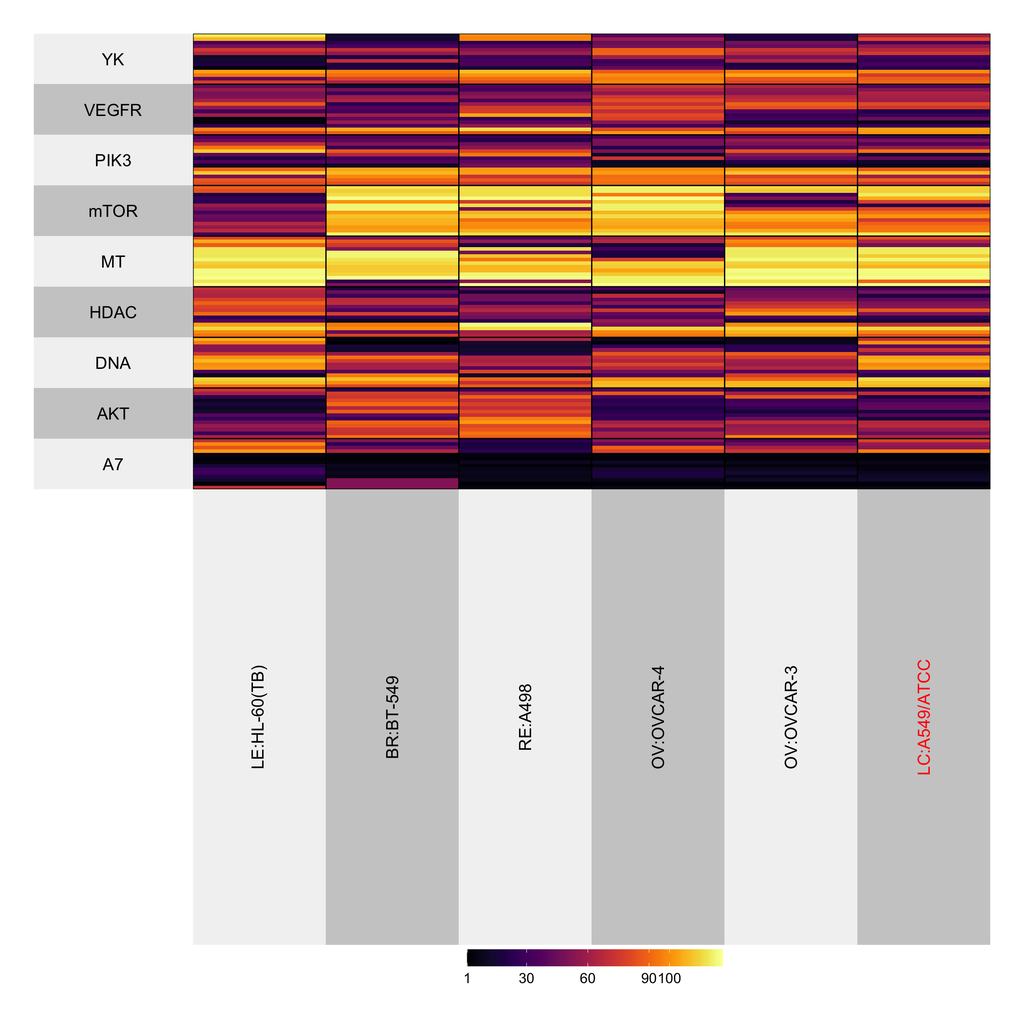

```r
# Plot distribution of compounds from select cell lines
ncell.plot <- 5
cell.select <- reshape2::melt(selected) %>%
  rename(CellLine=Var1, Ncell=Var2) %>%
  mutate(Ncell=ncell[Ncell])

cell.select.k <- cell.select %>%
  filter(Ncell == ncell.plot) %>%
  group_by(CellLine, Ncell) %>%
  summarize(Proportion=mean(value)) %>%
  ungroup() %>%
  top_n(ncell.plot, Proportion)
selected <- c(as.character(cell.select.k$CellLine), 'LC:A549/ATCC')
xplot <- apply(x[,selected], MAR=2, rank)
id.highlight <- colnames(xplot) == 'LC:A549/ATCC'

superheat(xplot,
          membership.rows=class.id,
          pretty.order.rows=TRUE,
          pretty.order.cols=TRUE,
          heat.pal=inferno(100),
          bottom.label.size=1,
          bottom.label.text.angle=90,
          bottom.label.text.col=ifelse(id.highlight, 'red', 'black'))
```

## Null predictive modeling - permuted responses

To assess performance against random chance, we repeat the experiment above using randomly permuted response labels.

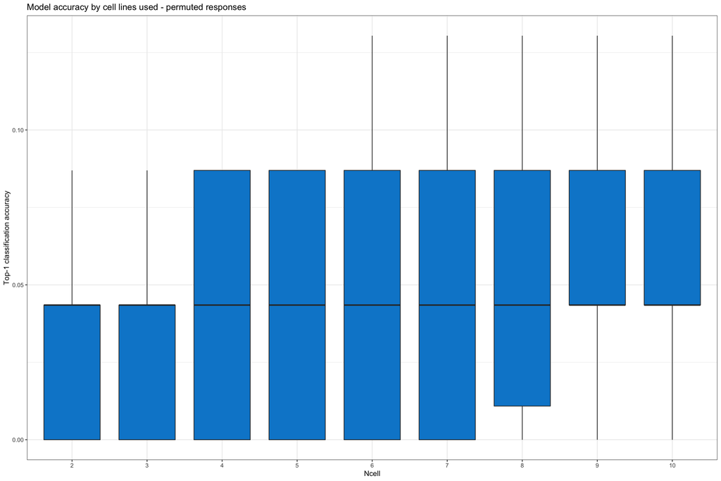

```r
fits.null <- mclapply(1:n.replicate, function(i) {
  set.seed(i)

  # Generate sample split
  id.train <- createDataPartition(y, p=train.prop)$Resample1
  id.test <- setdiff(1:nrow(x), id.train)

  # Fit lasso to predict moa from bioactivity
  yy <- sample(y)
  out <- model(x, yy, id.train, id.test, ncell)
  return(out$accuracy)
}, mc.cores=10)

accuracy <- lapply(fits.null, as.matrix)
reshape2::melt(accuracy) %>%
  mutate(Ncell=as.factor(ncell[Var1])) %>%
  ggplot(aes(x=Ncell, y=value)) +
  geom_boxplot(fill='#0388D1') +
  theme_bw() +
  ylab("Top-1 classification accuracy") +
  ggtitle('Model accuracy by cell lines used - permuted responses')
```

## Null predictive modeling - random cell lines

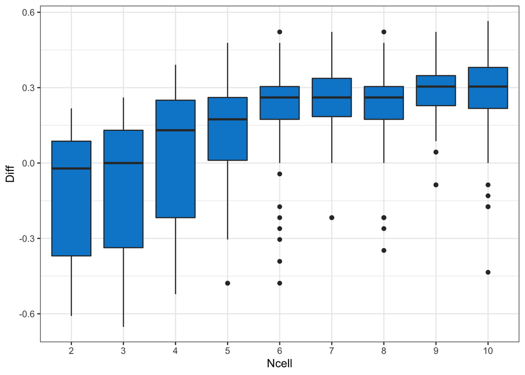

```r
# Drop single cell due to modeling constraints
fits.null <- mclapply(1:n.replicate, function(i) {
  set.seed(i)

  # Generate sample split
  id.train <- createDataPartition(y, p=train.prop)$Resample1
  id.test <- setdiff(1:nrow(x), id.train)

  # Fit RF to predict moa from bioactivity
  out.null <- model(x, y, id.train, id.test, ncell, null.cells=TRUE)
  out.opt <-  model(x, y, id.train, id.test, ncell)

  return(rbind(out.null$accuracy, out.opt$accuracy))
}, mc.cores=10)


reshape2::melt(fits.null) %>%
  rename(Selection=Var1, Ncell=Var2, Rep=L1) %>%
  mutate(Selection=ifelse(Selection == 1, 'Random', 'Optimal')) %>%
  mutate(Ncell=Ncell + 1) %>%
  mutate(Ncell=as.factor(Ncell)) %>%
  group_by(Ncell, Rep) %>%
  summarize(Diff=value[Selection == 'Optimal'] - value[Selection == 'Random']) %>%
  ggplot(aes(x=Ncell, y=Diff)) +
  geom_boxplot(fill='#0388D1') +
  theme_bw()
```